# Project 3: ChIP-seq Analysis Report

**Author:** Jinjie Liu

**Date:** November 2025

## Introduction

Transcription factors are pivotal regulators of gene expression that govern cellular identity and disease states by binding to specific DNA motifs; specifically, the transcription factor RUNX1, while essential for hematopoiesis, has also been implicated in the transcriptional program of breast cancer cells. This study was performed to delineate the genome-wide binding landscape of RUNX1 in MCF-7 cells and to elucidate its functional regulatory role by integrating binding events with differential gene expression data obtained from RNA-seq experiments. To achieve this, we employed Chromatin Immunoprecipitation sequencing (ChIP-seq), as it remains the gold standard for mapping protein-DNA interactions with high resolution across the entire genome. By utilizing a rigorous bioinformatics pipeline that includes read alignment, peak calling with HOMER, and motif enrichment analysis, we aim to identify high-confidence, reproducible binding sites and distinguish specific regulatory signals from background noise, thereby providing a mechanistic understanding of how this factor modulates the transcriptome.

## Methods

Read Pre-processing and Alignment Raw single-end sequencing reads were assessed for quality using FastQC (v0.12.1). Adapter sequences and low-quality bases were trimmed using Trimmomatic (v0.39) in single-end mode. The trimming parameters were set to ILLUMINACLIP:TruSeq3-SE.fa:2:30:10, LEADING:3, TRAILING:3, SLIDINGWINDOW:4:15, and MINLEN:36. Trimmed reads were aligned to the human reference genome (GRCh38/hg38) using Bowtie2 (v2.5.1) with default parameters. The resulting SAM files were converted to BAM format, sorted, and indexed using Samtools (v1.17). Alignment statistics were generated using samtools flagstat , and all quality control metrics were aggregated into a single report using MultiQC (v1.14).

Peak Calling and Filtering To identify genomic binding sites, tag directories were created from the sorted BAM files using HOMER (v4.11). Peak calling was performed using HOMER's findPeaks utility with the -style factor option, utilizing the corresponding Input sample as a control for each Immunoprecipitation (IP) replicate. To define a high-confidence set of binding sites, reproducible peaks were identified by taking the intersection of peaks called in both biological replicates using bedtools intersect (v2.31.0). Subsequently, peaks overlapping with ENCODE blacklisted regions (hg38-blacklist.v2.bed) were filtered out using bedtools intersect with the -v flag to remove signal artifacts.

Annotation, Motif Analysis, and Visualization The final set of reproducible, filtered peaks was annotated to the nearest genomic feature (e.g., promoter, intron, exon) using HOMER's annotatePeaks.pl with the GRCh38 genome and GENCODE v45 GTF annotation. De novo and known motif enrichment analysis was performed on these peaks using HOMER's findMotifsGenome.pl. For visualization, bigWig coverage tracks were generated using DeepTools bamCoverage (v3.5.1) with CPM (Counts Per Million) normalization. Sample correlation was assessed by calculating the Spearman correlation coefficient of read coverage in genomic bins using DeepTools multiBigwigSummary and plotCorrelation. Finally, the signal distribution across gene bodies (from 2kb upstream of the TSS to 2kb downstream of the TTS) was visualized using DeepTools computeMatrix in scale-regions mode followed by plotProfile.

# Quality Control Evaluation

The quality of the sequencing data was assessed using FastQC and MultiQC reports generated after adapter trimming and alignment. The sequencing depth across the four samples ranged from approximately 10.9 million reads (INPUT_rep2) to 30.1 million reads (INPUT_rep1), providing sufficient coverage for downstream analysis. While FastQC metrics indicated high duplication levels, particularly in the Immunoprecipitation (IP) samples (ranging from 74.3% to 89.1%), this is a characteristic feature of ChIP-seq experiments due to the preferential enrichment of specific genomic regions and PCR amplification. Potential adapter contamination and low-quality bases were effectively addressed using Trimmomatic prior to alignment, ensuring that overrepresented sequences did not interfere with mapping.

# Signal Coverage Plot

```
Signal Profile Across Gene Bodies (TSS to TTS):
```

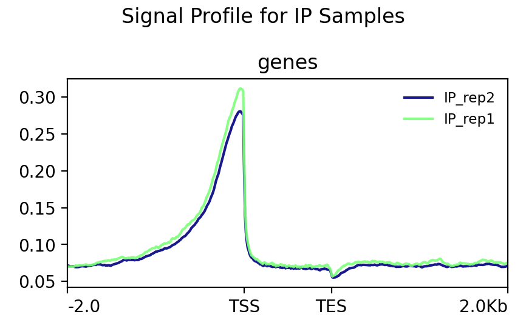

The signal coverage plot illustrates the average spatial distribution of RUNX1 binding events relative to the genomic architecture of all annotated human genes. As visualized in the figure, there is a distinct and sharp enrichment of ChIP-seq signal peaking precisely at and slightly upstream of the Transcription Start Site (TSS), with signal intensity rapidly decreasing across the gene body and remaining at background levels near the Transcription Termination Site (TES). The two biological replicates (IP_rep1 and IP_rep2) display highly consistent profiles, reinforcing the technical reproducibility of the experiment.

Biologically, this distinct binding pattern supports the hypothesis that RUNX1 functions primarily as a promoter-associated transcription factor in this cellular context (MCF-7). The strong localization at the TSS suggests that RUNX1 is directly involved in the initiation of transcription machinery recruitment or chromatin remodeling at gene promoters to regulate gene expression. The lack of sustained signal across the gene body indicates that, unlike elongation factors or certain histone modifications (e.g., H3K36me3), RUNX1 does not travel with the RNA polymerase II complex during transcription elongation but rather acts as a specific anchor at the regulatory start sites.

# Motif Finding

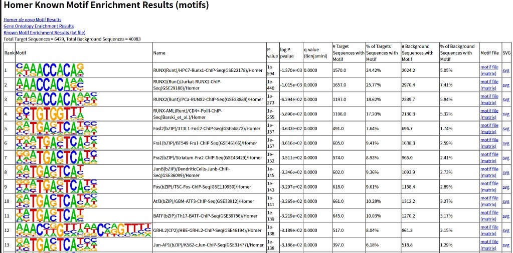

Motif enrichment analysis using HOMER’s findMotifsGenome.pl confirmed the high specificity of the ChIP-seq experiment. As shown in the figure, the RUNX consensus motifs (RUNX, RUNX1, RUNX2) were identified as the top-ranked hits with extremely high statistical significance (Rank 1 P-value $< 1 \times 10^{-594}$). The RUNX1 motif specifically was found in approximately 24-25% of the identified peaks, compared to only ~5-7% in background sequences, validating that the immunoprecipitation successfully targeted RUNX1-bound DNA regions.

Interestingly, the analysis also revealed significant enrichment for bZIP transcription factors, specifically members of the AP-1 complex (e.g., Fosl2, Fra1, JunB) in Ranks 5 through 11. The co-occurrence of AP-1 motifs with RUNX1 binding sites suggests a potential cooperative binding mechanism or co-localization at enhancer regions, where these factors may function synergistically to regulate gene expression in MCF-7 cells.

# Overlap the ChIPseq results with the original RNAseq data

To elucidate the functional regulatory role of RUNX1, we integrated our ChIP-seq binding data with differential gene expression data from the original RNA-seq experiment (GEO Accession GSE75070). We retrieved the lists of differentially expressed genes (up-regulated: $n=687$; down-regulated: $n=466$) based on the publication’s significance thresholds. Using pandas in Python, we overlapped these gene sets with the target genes identified in our ChIP-seq analysis (annotated to nearest promoter-TSS).Global Overlap Analysis (Figure 2F Recreation)We identified 132 up-regulated genes and 90 down-regulated genes that were directly bound by RUNX1 in our analysis.

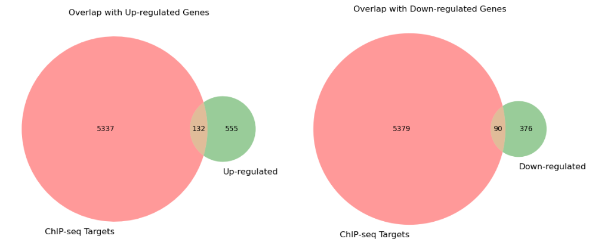

Visualization of Specific Targets (Figure 2D & 2E Recreation) The original publication highlighted MALAT1 and NEAT1 as key targets directly regulated by RUNX1. To validate this, we visualized the ChIP-seq signal tracks at these specific loci using IGV.

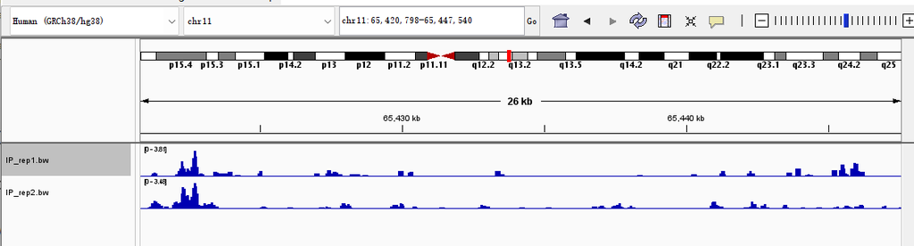

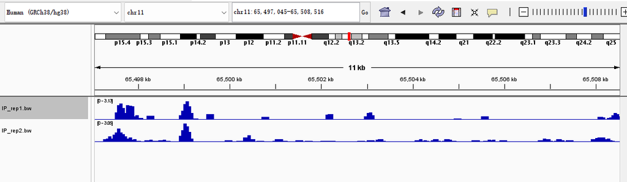

Discussion Comparison of Overlap Statistics (Figure 2F): We observed differences in the number of overlapping genes compared to the original Figure 2F. Our analysis identified 132 bound up-regulated genes, whereas the publication reported 59 (for TSS ±5kb) and 161 (for whole gene ±20kb). Two main factors likely contributed to these discrepancies:

- Annotation Strategy: The publication used rigid geometric windows (±5kb or ±20kb), whereas we used HOMER's "nearest promoter" annotation. Our method is more flexible than the narrow ±5kb window (hence identifying more targets) but more specific than the broad ±20kb window (hence identifying fewer targets), resulting in an intermediate number.
- Genome Build: We utilized the GRCh38 (hg38) assembly, whereas the original study likely used an older build (hg18/hg19). Differences in gene coordinates and annotations between versions can alter which peaks are assigned to which genes.

Rationale for Integration: Combining ChIP-seq and RNA-seq distinguishes direct regulatory targets from indirect downstream effects. Physical binding (ChIP-seq) does not always lead to functional regulation, and expression changes (RNA-seq) can be secondary effects. Identifying the intersection (Overlap) enables us to pinpoint high-confidence direct targets where RUNX1 binding physically drives transcriptional changes.

Analysis of MALAT1 and NEAT1: Our analysis confirms that both MALAT1 and NEAT1 are significant targets.

- Statistical Significance: Both genes were present in our annotated_peaks.txt file, indicating they contain statistically significant peaks (FDR < 0.001) that passed our reproducibility filters.
- Track Similarity: The genomic tracks generated from our pipeline closely resemble those in the paper (Figures 2D/E). Both replicates (IP_rep1 and IP_rep2) show distinct, sharp enrichment peaks at the promoter regions of MALAT1 and NEAT1, with negligible background signal, confirming these are robust, high-confidence binding sites.

# Comparing key findings to the original paper

Sequencing Depth and Alignment Statistics (Table S2A).

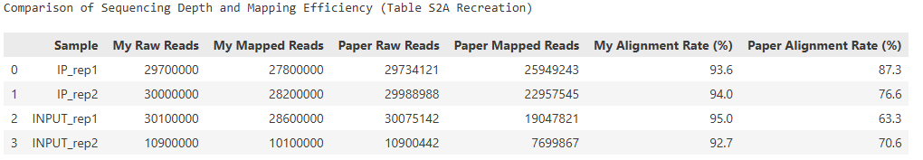

We re-created the sequencing statistics table found in Supplementary Figure S2A to compare our processing metrics with the original study. While the number of raw reads was identical to the reported values, confirming the use of the same dataset, we observed a discrepancy in the number of mapped reads. Our pipeline achieved consistently higher alignment rates (e.g., 95.0% for INPUT_rep1 compared to the published 63.3%). This improvement is likely attributable to two main factors: first, the evolution of alignment algorithms, where our use of Bowtie2 (which handles gapped alignments) outperforms the older aligners likely used in the 2011 publication; and second, the use of the GRCh38 (hg38) reference genome, which offers a more complete assembly than the older builds (hg18/hg19), allowing more reads to be successfully mapped to unique genomic locations.

Correlation Analysis (Figure S2B)

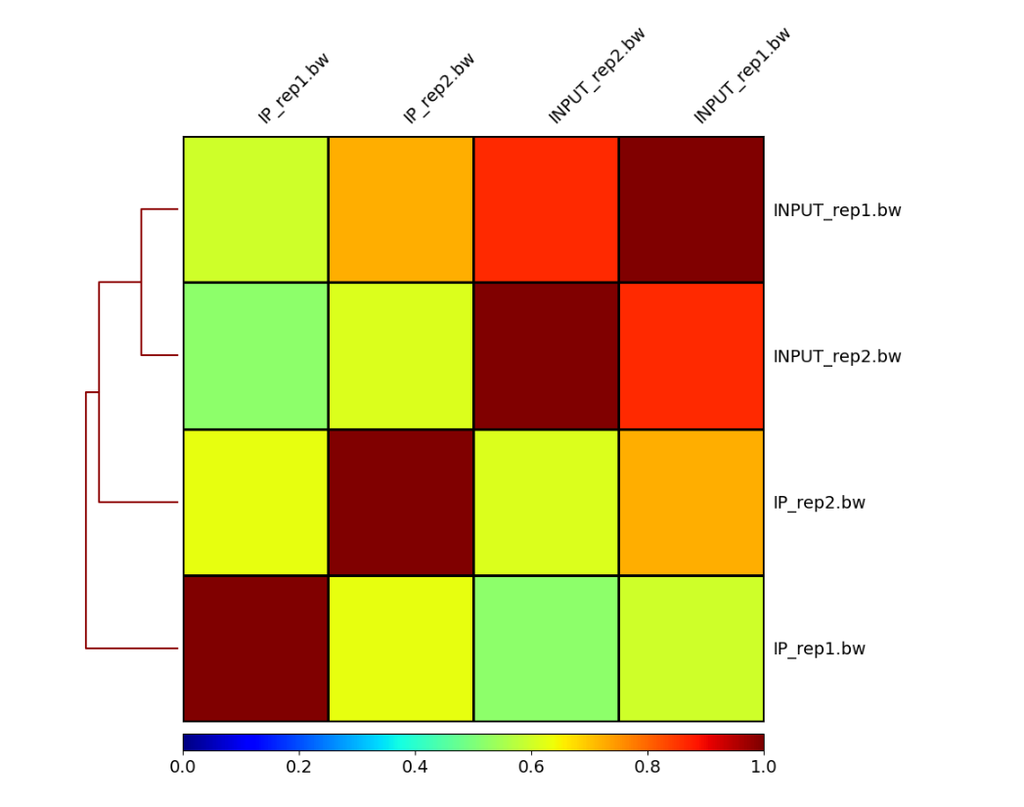

Peak Reproducibility (Figure S2C)

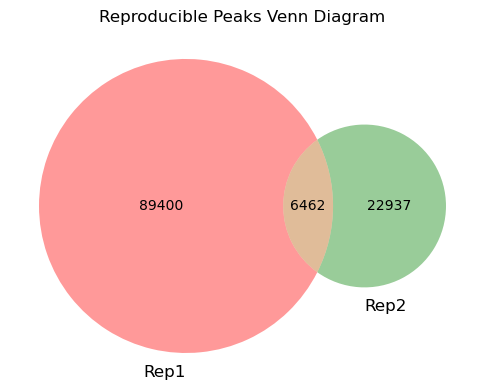

We generated a Venn diagram to assess peak reproducibility between replicates and compared it to Supplementary Figure S2C. Our analysis identified 6,462 reproducible peaks (intersection), which differs from the approximately 3,500 overlapping peaks reported in the original study. This discrepancy in called peaks can be explained by two factors. First, differences in peak calling software: we utilized HOMER, whereas the original study likely employed a different algorithm (e.g., MACS), and different callers have varying sensitivity and background models. Second, the intersection strategy: we defined reproducibility using a direct genomic overlap (bedtools intersect), while the authors may have applied a more conservative statistical method, such as the Irreproducible Discovery Rate (IDR), or used different FDR thresholds during peak calling, resulting in a more restricted consensus set.

# Analyze the Annotated Peaks

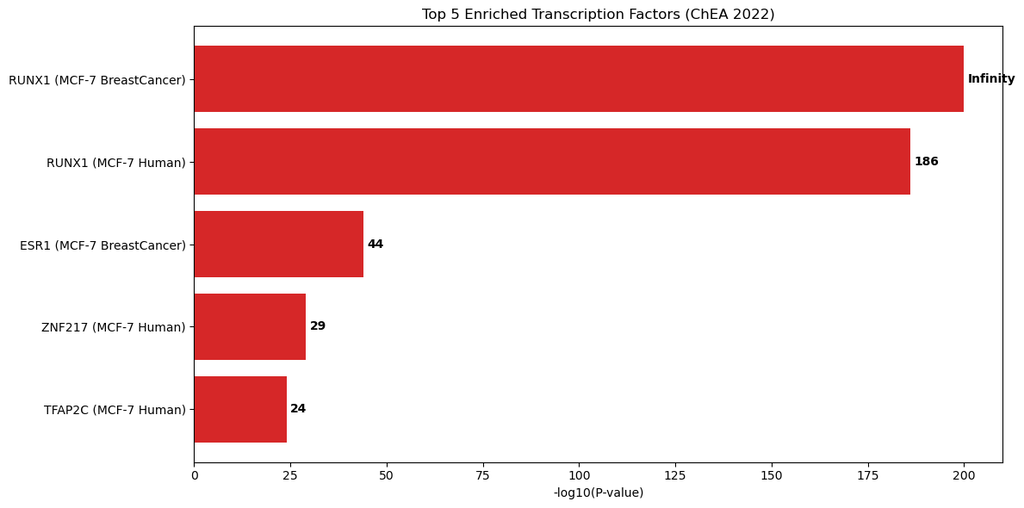

Figure Legend: Top enriched transcription factors identified by Enrichr using the ChEA 2022 database. The bar chart displays the enrichment significance (-log10 P-value) for the top 5 transcription factors associated with the genes bound by RUNX1.

Methodology and Results Commentary:To characterize the regulatory network associated with our reproducible peaks, we extracted the list of target gene names from our annotated peaks file and performed a transcription factor enrichment analysis using the Enrichr platform (ChEA 2022 database) 1. The analysis yielded highly significant results that validate the experimental design. As shown in the figure, RUNX1 in MCF-7 cells was identified as the top enriched term (P-value $\approx 0$), serving as a definitive positive control that confirms the ChIP-seq experiment successfully targeted the correct protein in the correct cell line. Furthermore, the analysis revealed a significant enrichment for ESR1 (Estrogen Receptor alpha). Since MCF-7 is an ER-positive breast cancer cell line, this finding is biologically interesting as it suggests a potential co-regulatory relationship or crosstalk between RUNX1 and Estrogen Receptor signaling pathways in driving the transcriptional program of these cancer cells2.